# Credit Card Users Churn Prediction

# Feature Engineering

## Outliers Treatment

### Lets check the percentage of Outliers with IQR

```python
outlier_num = ccardDf.select_dtypes(include=np.number)

# find the 25th percentile and 75th percentile.
Q1 = ccardDf.quantile(0.25)
Q3 = ccardDf.quantile(0.75)

# Inter Quantile Range (75th percentile - 25th percentile)
IQR = Q3 - Q1

# find lower and upper bounds for all values. All values outside these bounds are outliers
lower=Q1-1.5*IQR
upper=Q3+1.5*IQR

df_outliers = pd.DataFrame(((outlier_num<lower)|(outlier_num>upper)).sum()/len(ccardDf)*100)
df_outliers
```

|  | 0 |
| --- | --- |
| Attrition_Flag | 16.066 |
| Customer_Age | 0.020 |
| Dependent_count | 0.000 |
| Months_on_book | 3.812 |
| Total_Relationship_Count | 0.000 |
| Months_Inactive_12_mon | 3.268 |
| Contacts_Count_12_mon | 6.211 |
| Credit_Limit | 9.717 |
| Total_Revolving_Bal | 0.000 |
| Avg_Open_To_Buy | 9.509 |
| Total_Amt_Chng_Q4_Q1 | 3.910 |
| Total_Trans_Amt | 8.848 |
| Total_Trans_Ct | 0.020 |
| Total_Ct_Chng_Q4_Q1 | 3.891 |
| Avg_Utilization_Ratio | 0.000 |

**Observations:**

1. Credit_Limit, Avg_Open_To_Buy, Total_Trans_Amt have large number of outliers
2. `Months_On_Book, Months_Inactive_12_mon,Contacts_Count_12_mon, Total_Amnt_Chng_Q4_Q1,Total_Ct_Chng_Q4_Q1 have few outliers.
3. `Attrition_Flag` is a target variable, this shows the data is not balanced, we can do oversampling and undersampling to balance this data.
4. Since I am choosing to build DecisionTree Based models and they are not influenced by Outliers, we can choose either choose to treat or not to treat.
- In this case I have decided not to treat them as there will be outliers in real case scenario where we deal with huge set of data the values in the fields age, the total amount of transactions and number of transactions will be more balanced and the model should be able to learn the pattern for different customers

### Missing Value Treatment

Replace the value 'abc' in Income_Category column with Nan and do a missing value treatment.

```python
ccardDf["Income_Category"].replace("abc", np.nan, inplace=True)
```

#### Heatmap of Missing Data

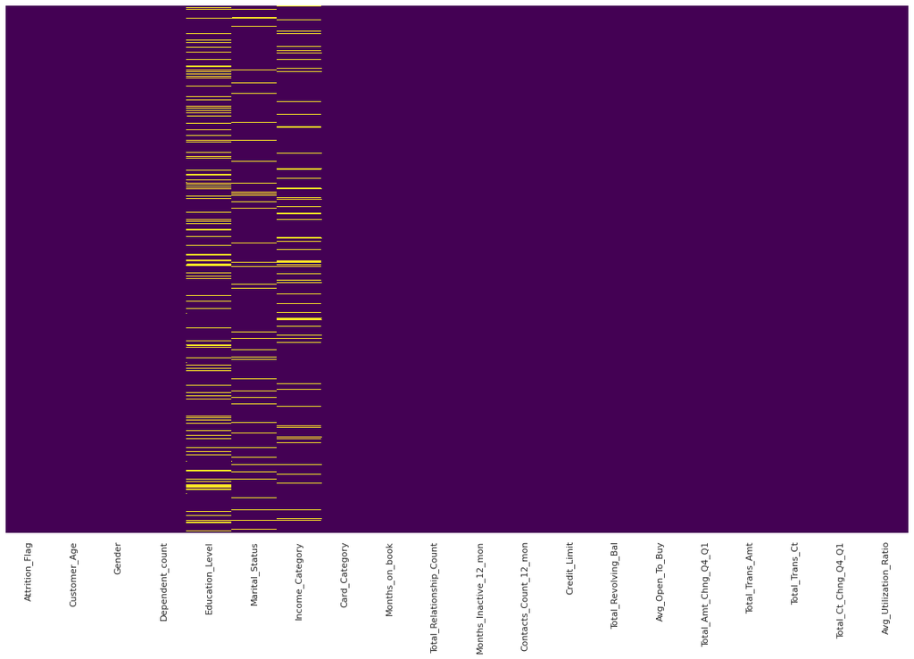

```python
plt.figure(figsize=(20, 12))
sns.heatmap(ccardDf.isnull(),yticklabels=False,cbar=False,cmap='viridis')
plt.show()
```

- The above heatmap of missing data shows that the data is missing at random in some of the columns.
- Let us consider imputing the missing values using median for continuous variables and most frequent value for categorical variables.

```python
# round((tourismDf.isnull().sum()*100)/len(tourismDf),2).sort_values()
ccardDf.isnull().sum().sort_values()
```

```
Attrition_Flag                 0
Total_Trans_Ct                 0
Total_Trans_Amt                0
Total_Amt_Chng_Q4_Q1           0
Avg_Open_To_Buy                0
Total_Revolving_Bal            0
Credit_Limit                   0
Contacts_Count_12_mon          0
Months_Inactive_12_mon         0
Total_Relationship_Count       0
Months_on_book                 0
Card_Category                  0
Dependent_count                0
Gender                         0
Customer_Age                   0
Total_Ct_Chng_Q4_Q1            0
Avg_Utilization_Ratio          0
Marital_Status               749
Income_Category             1112
Education_Level             1519
dtype: int64
```

- `Education_Level` has 1519 missing values
- `Income_Category` has 1112 missing values
- `Marital_Status` has 749 missing values

Let us start with the column that has least number of missing values

#### Using Simple Imputer for missing value Treatment

- We will use SimpleImputer to impute missing values and replace the missing values with the most_fequent occurance, since above mentioned columns are considered categorical values.

**The values obtained might not be integer always which is not be the best way to impute categorical values**

- I am going to replace the categorical data with numeric values before imputation for better interpretation and imputation.

```python
ccardDf.isnull().sum()
```

```
Attrition_Flag                 0
Customer_Age                   0
Gender                         0
Dependent_count                0
Education_Level             1519
Marital_Status               749
Income_Category             1112
Card_Category                  0
Months_on_book                 0
Total_Relationship_Count       0
Months_Inactive_12_mon         0
Contacts_Count_12_mon          0
Credit_Limit                   0
Total_Revolving_Bal            0
Avg_Open_To_Buy                0
Total_Amt_Chng_Q4_Q1           0
Total_Trans_Amt                0
Total_Trans_Ct                 0
Total_Ct_Chng_Q4_Q1            0
Avg_Utilization_Ratio          0
dtype: int64
```

```python
# defining a list with names of columns that will be used for imputation
reqd_col_for_impute = [
    "Education_Level",
    "Marital_Status",
    "Income_Category"
]
```

```python
ccardDf[reqd_col_for_impute].head()
```

|  | Education_Level | Marital_Status | Income_Category |
| --- | --- | --- | --- |
| 0 | High School | Married | $60K - $80K |
| 1 | Graduate | Single | Less than $40K |
| 2 | Graduate | Married | $80K - $120K |
| 3 | High School | NaN | Less than $40K |
| 4 | Uneducated | Married | $60K - $80K |

```python
ccardDf.Education_Level.unique()
```

```
array(['High School', 'Graduate', 'Uneducated', nan, 'College',
       'Post-Graduate', 'Doctorate'], dtype=object)
```

```python
# we need to pass numerical values for each categorical column for KNN imputation so we will label encode them
Education_Level = {"Uneducated": 0, "High School": 1, "College": 2,"Graduate": 3,"Post-Graduate": 4,"Doctorate": 5}
ccardDf["Education_Level"] = ccardDf["Education_Level"].map(Education_Level)
```

```python
ccardDf.Marital_Status.unique()
```

```
array(['Married', 'Single', nan, 'Divorced'], dtype=object)
```

```python
Marital_Status = {"Single":0,"Married":1,"Divorced":2}
ccardDf["Marital_Status"] = ccardDf["Marital_Status"].map(Marital_Status)
```

```python
ccardDf.Income_Category.unique()
```

```
array(['$60K - $80K', 'Less than $40K', '$80K - $120K', '$40K - $60K',
       '$120K +', nan], dtype=object)
```

```python
Income_Category = {"Less than $40K":0, "$40K - $60K":1, "$60K - $80K":2, "$80K - $120K":3,"$120K +":4}
ccardDf["Income_Category"] = ccardDf["Income_Category"].map(Income_Category)
```

```python
ccardDf.head()
```

|  | Attrition_Flag | Customer_Age | Gender | Dependent_count | Education_Level | Marital_Status | Income_Category | Card_Category | Months_on_book | Total_Relationship_Count | Months_Inactive_12_mon | Contacts_Count_12_mon | Credit_Limit | Total_Revolving_Bal | Avg_Open_To_Buy | Total_Amt_Chng_Q4_Q1 | Total_Trans_Amt | Total_Trans_Ct | Total_Ct_Chng_Q4_Q1 | Avg_Utilization_Ratio |
| --- | --- | --- | --- | --- | --- | --- | --- | --- | --- | --- | --- | --- | --- | --- | --- | --- | --- | --- | --- | --- |
| 0 | 0 | 45 | M | 3 | 1.000 | 1.000 | 2.000 | Blue | 39 | 5 | 1 | 3 | 12691.000 | 777 | 11914.000 | 1.335 | 1144 | 42 | 1.625 | 0.061 |
| 1 | 0 | 49 | F | 5 | 3.000 | 0.000 | 0.000 | Blue | 44 | 6 | 1 | 2 | 8256.000 | 864 | 7392.000 | 1.541 | 1291 | 33 | 3.714 | 0.105 |
| 2 | 0 | 51 | M | 3 | 3.000 | 1.000 | 3.000 | Blue | 36 | 4 | 1 | 0 | 3418.000 | 0 | 3418.000 | 2.594 | 1887 | 20 | 2.333 | 0.000 |
| 3 | 0 | 40 | F | 4 | 1.000 | NaN | 0.000 | Blue | 34 | 3 | 4 | 1 | 3313.000 | 2517 | 796.000 | 1.405 | 1171 | 20 | 2.333 | 0.760 |
| 4 | 0 | 40 | M | 3 | 0.000 | 1.000 | 2.000 | Blue | 21 | 5 | 1 | 0 | 4716.000 | 0 | 4716.000 | 2.175 | 816 | 28 | 2.500 | 0.000 |

- Values have been encoded.

### Data Preparation for Modeling

```python
X = ccardDf.drop(["Attrition_Flag"], axis=1)
y = ccardDf["Attrition_Flag"]
```

```python
# Splitting data into training, validation and test set:
# first we split data into 2 parts, say temporary and test

X_temp, X_test, y_temp, y_test = train_test_split(
    X, y, test_size=0.2, random_state=1, stratify=y
)

# then we split the temporary set into train and validation

X_train, X_val, y_train, y_val = train_test_split(
    X_temp, y_temp, test_size=0.25, random_state=1, stratify=y_temp
)
print(X_train.shape, X_val.shape, X_test.shape)
```

```
(6075, 19) (2026, 19) (2026, 19)
```

```python
print("Number of rows in train data =", X_train.shape[0])
print("Number of rows in validation data =", X_val.shape[0])
print("Number of rows in test data =", X_test.shape[0])
```

```
Number of rows in train data = 6075
Number of rows in validation data = 2026
Number of rows in test data = 2026
```

# Rectification:

**Imputing Missing Values**

```python
imputer = SimpleImputer(strategy="most_frequent")
```

```python
# Fit and transform the train data
X_train[reqd_col_for_impute] = imputer.fit_transform(X_train[reqd_col_for_impute])

# Transform the validation data
X_val[reqd_col_for_impute] = imputer.transform(X_val[reqd_col_for_impute])

# Transform the test data
X_test[reqd_col_for_impute] = imputer.transform(X_test[reqd_col_for_impute])
```

```python
# Checking that no column has missing values in train, validation or test sets
print(X_train.isna().sum())
print("-" * 30)
print(X_val.isna().sum())
print("-" * 30)
print(X_test.isna().sum())
```

```
Customer_Age                0
Gender                      0
Dependent_count             0
Education_Level             0
Marital_Status              0
Income_Category             0
Card_Category               0
Months_on_book              0
Total_Relationship_Count    0
Months_Inactive_12_mon      0
Contacts_Count_12_mon       0
Credit_Limit                0
Total_Revolving_Bal         0
Avg_Open_To_Buy             0
Total_Amt_Chng_Q4_Q1        0
Total_Trans_Amt             0
Total_Trans_Ct              0
Total_Ct_Chng_Q4_Q1         0
Avg_Utilization_Ratio       0
dtype: int64
------------------------------
Customer_Age                0
Gender                      0
Dependent_count             0
Education_Level             0
Marital_Status              0
Income_Category             0
Card_Category               0
Months_on_book              0
Total_Relationship_Count    0
Months_Inactive_12_mon      0
Contacts_Count_12_mon       0
Credit_Limit                0
Total_Revolving_Bal         0
Avg_Open_To_Buy             0
Total_Amt_Chng_Q4_Q1        0
Total_Trans_Amt             0
Total_Trans_Ct              0
Total_Ct_Chng_Q4_Q1         0
Avg_Utilization_Ratio       0
dtype: int64
------------------------------
Customer_Age                0
Gender                      0
Dependent_count             0
Education_Level             0
Marital_Status              0
Income_Category             0
Card_Category               0
Months_on_book              0
Total_Relationship_Count    0
Months_Inactive_12_mon      0
Contacts_Count_12_mon       0
Credit_Limit                0
Total_Revolving_Bal         0
Avg_Open_To_Buy             0
Total_Amt_Chng_Q4_Q1        0
Total_Trans_Amt             0
Total_Trans_Ct              0
Total_Ct_Chng_Q4_Q1         0
Avg_Utilization_Ratio       0
dtype: int64
```

- All missing values have been treated.
- Let's inverse map the encoded values.

```python
## Function to inverse the encoding
def inverse_mapping(x, y):
    inv_dict = {v: k for k, v in x.items()}
    X_train[y] = np.round(X_train[y]).map(inv_dict).astype("category")
    X_val[y] = np.round(X_val[y]).map(inv_dict).astype("category")
    X_test[y] = np.round(X_test[y]).map(inv_dict).astype("category")
```

```python
inverse_mapping(Education_Level, "Education_Level")
inverse_mapping(Marital_Status, "Marital_Status")
inverse_mapping(Income_Category, "Income_Category")
```

- Checking inverse mapped values/categories.

```python
cols = X_train.select_dtypes(include=["object", "category"])
for i in cols.columns:
    print(X_train[i].value_counts())
    print("*" * 30)
```

```
F    3193
M    2882
Name: Gender, dtype: int64
Graduate         2782
High School      1228
Uneducated        881
College           618
Post-Graduate     312
Doctorate         254
Name: Education_Level, dtype: int64
Married     3276
Single      2369
Divorced     430
Name: Marital_Status, dtype: int64
Less than $40K    2783
$40K - $60K       1059
$80K - $120K       953
$60K - $80K        831
$120K +            449
Name: Income_Category, dtype: int64
Blue        5655
Silver       339
Gold          69
Platinum      12
Name: Card_Category, dtype: int64
```

```python
cols = X_val.select_dtypes(include=["object", "category"])
for i in cols.columns:
    print(X_val[i].value_counts())
    print("*" * 30)
```

```
F    1095
M     931
Name: Gender, dtype: int64
Graduate         917
High School      404
Uneducated       306
College          199
Post-Graduate    101
Doctorate         99
Name: Education_Level, dtype: int64
Married     1100
Single       770
Divorced     156
Name: Marital_Status, dtype: int64
Less than $40K    957
$40K - $60K       361
$80K - $120K      293
$60K - $80K       279
$120K +           136
Name: Income_Category, dtype: int64
Blue        1905
Silver        97
Gold          21
Platinum       3
Name: Card_Category, dtype: int64
```

```python
cols = X_test.select_dtypes(include=["object", "category"])
for i in cols.columns:
    print(X_test[i].value_counts())
    print("*" * 30)
```

```
F    1070
M     956
Name: Gender, dtype: int64
Graduate         948
High School      381
Uneducated       300
College          196
Post-Graduate    103
Doctorate         98
Name: Education_Level, dtype: int64
Married     1060
Single       804
Divorced     162
Name: Marital_Status, dtype: int64
Less than $40K    933
$40K - $60K       370
$60K - $80K       292
$80K - $120K      289
$120K +           142
Name: Income_Category, dtype: int64
Blue        1876
Silver       119
Gold          26
Platinum       5
Name: Card_Category, dtype: int64
```

- Inverse mapping returned original labels.

### Creating Dummy Variables

```python
X_train = pd.get_dummies(X_train)
X_val = pd.get_dummies(X_val)
X_test = pd.get_dummies(X_test)
print(X_train.shape, X_val.shape, X_test.shape)
```

```
(6075, 34) (2026, 34) (2026, 34)
```

- After encoding there are 34 columns.